# One-Way ANOVA

ChatGPT 4o

2025-01-21

## 1 起源

单因素方差分析（One-Way ANOVA）起源于统计学家罗纳德·费舍尔（Ronald A. Fisher）的研究，最初用于农业实验中的数据分析。费舍尔发明了方差分析这一方法，以比较多组实验数据之间的均值差异，从而确定某种处理手段是否对实验结果有显著影响。单因素方差分析最早用于研究不同施肥方式对作物产量的影响，后来被广泛应用于各个科学领域。

## 2 原理

单因素方差分析是一种用于比较多组样本均值差异的统计方法。其核心思想是通过比较组间变异与组内变异的大小，判断不同组之间是否存在显著的均值差异。单因素方差分析的假设检验过程包括：

- **原假设（$H_0$）**：所有组的均值相等，即各组之间无显著差异。
- **备择假设（$H_1$）**：至少有一组的均值与其他组不同。

通过计算方差比率（F值），并与F分布的临界值进行比较，可以判断是否拒绝原假设。如果F值足够大，意味着组间变异显著大于组内变异，从而可以认为不同组之间存在显著差异。

单因素方差分析的主要步骤包括：

1. **计算总变异**：总变异来源于所有观测值与总体均值的差异。
2. **分解为组间变异和组内变异**：组间变异衡量不同组均值之间的差异，组内变异衡量每组内部数据的波动。
3. **计算F统计量**：通过组间均方（MSB）和组内均方（MSW）的比值计算F值。

公式如下：

$$F = \frac{MSB}{MSW}$$

其中，$MSB$ 表示组间均方，$MSW$ 表示组内均方。

## 3 适用范围

单因素方差分析适用于以下情况：

- **因变量**：因变量为连续型数据，且满足正态性假设。
- **自变量**：自变量为分类变量，且包含两个或两个以上的独立组。
- **方差齐性**：各组数据的方差应相等，即满足方差齐性假设。

单因素方差分析常用于检测多个实验组之间的均值差异，适用于实验设计中只有一个因素的情况，如不同教学方法、不同药物剂量等对结果的影响。

## 4 应用情境

单因素方差分析在许多实际应用中都有广泛的应用。例如：

- **农业研究**：比较不同施肥方式对作物产量的影响。
- **医学实验**：比较不同药物剂量对病人血压的影响。
- **教育研究**：比较不同教学方法对学生成绩的影响。
- **市场研究**：比较不同广告策略对消费者购买意向的影响。

## 5 优缺点

### 优点

- **适用于多组比较**：单因素方差分析可以同时比较多个组的均值，避免了多次t检验带来的显著性水平问题。
- **简单易懂**：其计算过程和结果解释相对简单，便于理解和应用。

### 缺点

- **对正态性和方差齐性的要求较高**：单因素方差分析要求数据服从正态分布，且各组方差相等。如果不满足这些假设，结果的可靠性可能受到影响。
- **无法识别具体差异的组别**：当拒绝原假设时，单因素方差分析只能说明存在显著差异，但无法识别具体哪两组之间存在差异，需要进一步的事后检验（如Tukey检验）。

## 6 在R中的实现及结果解释

在R中，单因素方差分析可以通过`aov()`函数实现。以下是一个实现示例：

```r
# 示例数据：不同教学方法对学生成绩的影响
teaching_method <- factor(rep(c("A", "B", "C"), each = 10))
score <- c(85, 88, 90, 87, 86, 89, 91, 92, 84, 87,
           78, 82, 80, 79, 81, 83, 85, 84, 80, 81,
           92, 94, 93, 95, 91, 90, 96, 94, 93, 92)

# 创建数据框
data <- data.frame(TeachingMethod = teaching_method, Score = score)
data
```

```
##    TeachingMethod Score
## 1               A    85
## 2               A    88
## 3               A    90
## 4               A    87
## 5               A    86
## 6               A    89
## 7               A    91
## 8               A    92
## 9               A    84
## 10              A    87
## 11              B    78
## 12              B    82
## 13              B    80
## 14              B    79
```

[output cut: 16 more lines]

```r
# 进行单因素方差分析
anova_result <- aov(Score ~ TeachingMethod, data = data)
anova_result
```

```
## Call:
##    aov(formula = Score ~ TeachingMethod, data = data)
##
## Terms:
##                 TeachingMethod Residuals
## Sum of Squares           688.2     135.0
## Deg. of Freedom              2        27
##
## Residual standard error: 2.236068
## Estimated effects may be unbalanced
```

```r
str(anova_result)
```

[output not shown]

```r
anova_result$coef
```

```
##     (Intercept) TeachingMethodB TeachingMethodC
##            87.9            -6.6             5.1
```

```r
coef(anova_result)
```

```
##     (Intercept) TeachingMethodB TeachingMethodC
##            87.9            -6.6             5.1
```

```r
fitted(anova_result)
```

```
##    1    2    3    4    5    6    7    8    9   10   11   12   13   14   15   16
## 87.9 87.9 87.9 87.9 87.9 87.9 87.9 87.9 87.9 87.9 81.3 81.3 81.3 81.3 81.3 81.3
##   17   18   19   20   21   22   23   24   25   26   27   28   29   30
## 81.3 81.3 81.3 81.3 93.0 93.0 93.0 93.0 93.0 93.0 93.0 93.0 93.0 93.0
```

```r
residuals(anova_result)
```

```
##             1             2             3             4             5
## -2.900000e+00  1.000000e-01  2.100000e+00 -9.000000e-01 -1.900000e+00
##             6             7             8             9            10
##  1.100000e+00  3.100000e+00  4.100000e+00 -3.900000e+00 -9.000000e-01
##            11            12            13            14            15
## -3.300000e+00  7.000000e-01 -1.300000e+00 -2.300000e+00 -3.000000e-01
##            16            17            18            19            20
##  1.700000e+00  3.700000e+00  2.700000e+00 -1.300000e+00 -3.000000e-01
##            21            22            23            24            25
## -1.000000e+00  1.000000e+00  1.110223e-16  2.000000e+00 -2.000000e+00
##            26            27            28            29            30
## -3.000000e+00  3.000000e+00  1.000000e+00  1.110223e-16 -1.000000e+00
```

```r
anova(anova_result)
```

```
## Analysis of Variance Table
##
## Response: Score
##                Df Sum Sq Mean Sq F value    Pr(>F)
## TeachingMethod  2  688.2   344.1   68.82 2.513e-11 ***
## Residuals      27  135.0     5.0
## ---
## Signif. codes:  0 '***' 0.001 '**' 0.01 '*' 0.05 '.' 0.1 ' ' 1
```

```r
# 输出结果
summary(anova_result)
```

```
##                Df Sum Sq Mean Sq F value   Pr(>F)
## TeachingMethod  2  688.2   344.1   68.82 2.51e-11 ***
## Residuals      27  135.0     5.0
## ---
## Signif. codes:  0 '***' 0.001 '**' 0.01 '*' 0.05 '.' 0.1 ' ' 1
```

### 结果解释

运行上述代码后，将输出单因素方差分析的结果，主要包括以下内容：

- **Df（自由度）**：表示组间和组内的自由度。
- **Sum Sq（平方和）**：表示组间和组内的平方和，用于计算变异。
- **Mean Sq（均方）**：表示平方和除以自由度得到的均方。
- **F value**：表示组间均方与组内均方的比值。
- **Pr(>F)**：表示p值，用于判断原假设是否成立。如果p值小于显著性水平（如0.05），则拒绝原假设，说明组间均值之间存在显著差异。
- **F value = 68.82**：表示F统计量的值。
- **p-value = 2.51e-11**：p值小于0.05，说明在95%的置信水平下，可以拒绝原假设，表明不同教学方法之间存在显著差异。

### 假设条件的诊断

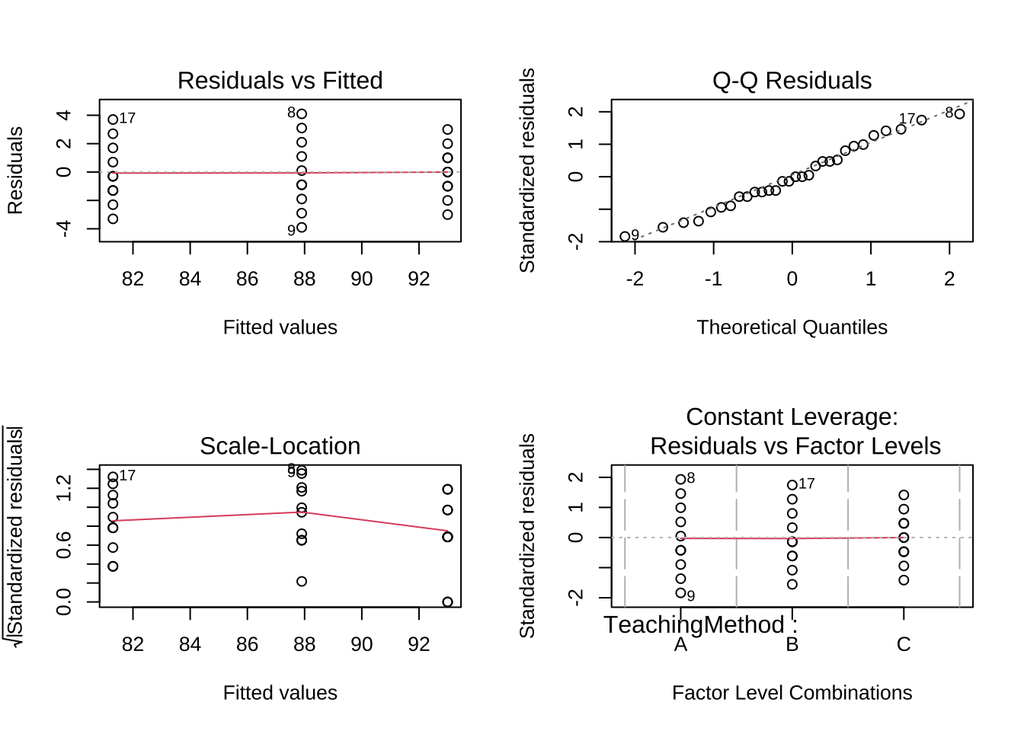

[output not shown]

```r
# 假设条件的诊断图
par(mfrow = c(2, 2))
plot(anova_result)
```

### 结果的可视化

可以使用R中的`ggplot2`包对结果进行可视化，以更直观地展示各组均值的差异。

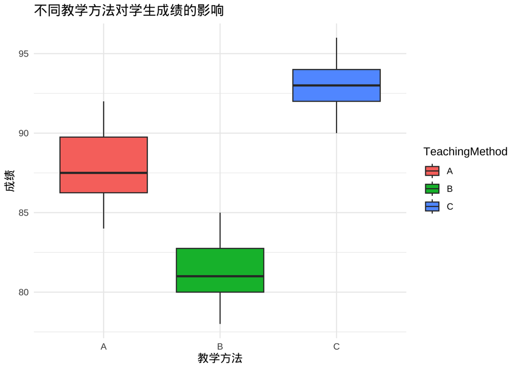

```r
# 加载ggplot2包
library(ggplot2)

# 绘制箱线图
ggplot(data, aes(x = TeachingMethod, y = Score, fill = TeachingMethod)) +
  geom_boxplot() +
  labs(title = "不同教学方法对学生成绩的影响", x = "教学方法", y = "成绩") +
  theme_minimal()
```

上述代码将绘制一个箱线图，用于展示不同教学方法对学生成绩的分布情况，通过比较箱线图可以更直观地看到各组之间的差异。

### 多重比较

当单因素方差分析的结果显示不同组之间存在显著差异时，需要进一步进行多重比较，以确定具体哪些组之间存在差异。R中可以使用`TukeyHSD()`函数进行多重比较。

```r
# 进行多重比较（Tukey检验）
tukey_result <- TukeyHSD(anova_result)

# 输出多重比较结果
print(tukey_result)
```

```
##   Tukey multiple comparisons of means
##     95% family-wise confidence level
##
## Fit: aov(formula = Score ~ TeachingMethod, data = data)
##
## $TeachingMethod
##     diff       lwr       upr    p adj
## B-A -6.6 -9.079418 -4.120582 1.30e-06
## C-A  5.1  2.620582  7.579418 6.74e-05
## C-B 11.7  9.220582 14.179418 0.00e+00
```

### 多重比较结果解释

多重比较的结果包括各组之间的均值差异的估计值、置信区间和p值。如果p值小于显著性水平（如0.05），则表明这两组之间的均值差异显著。

### 等价方法

```r
# 一般线性模型General Linear Model
# 上面的结果与一般线性模型的结果相同
lm_result <- lm(Score ~ TeachingMethod, data = data)
summary(lm_result)
```

```
##
## Call:
## lm(formula = Score ~ TeachingMethod, data = data)
##
## Residuals:
##    Min     1Q Median     3Q    Max
##  -3.90  -1.30  -0.15   1.55   4.10
##
## Coefficients:
##                 Estimate Std. Error t value Pr(>|t|)
## (Intercept)      87.9000     0.7071   124.3  < 2e-16 ***
## TeachingMethodB  -6.6000     1.0000    -6.6 4.43e-07 ***
## TeachingMethodC   5.1000     1.0000     5.1 2.33e-05 ***
## ---
## Signif. codes:  0 '***' 0.001 '**' 0.01 '*' 0.05 '.' 0.1 ' ' 1
##
## Residual standard error: 2.236 on 27 degrees of freedom
## Multiple R-squared:  0.836,  Adjusted R-squared:  0.8239
## F-statistic: 68.82 on 2 and 27 DF,  p-value: 2.513e-11
```

```r
coef(anova_result)
```

```
##     (Intercept) TeachingMethodB TeachingMethodC
##            87.9            -6.6             5.1
```

```r
anova(anova_result)
```

```
## Analysis of Variance Table
##
## Response: Score
##                Df Sum Sq Mean Sq F value    Pr(>F)
## TeachingMethod  2  688.2   344.1   68.82 2.513e-11 ***
## Residuals      27  135.0     5.0
## ---
## Signif. codes:  0 '***' 0.001 '**' 0.01 '*' 0.05 '.' 0.1 ' ' 1
```

## 7 小结

- 单因素方差分析用于比较多个组的均值差异，判断不同处理组之间是否存在显著差异。
- 其优点是可以同时比较多组，简单易懂，但对数据的正态性和方差齐性有较高要求。
- 通过R中的`aov()`函数可以实现单因素方差分析，结合可视化可以更好地展示结果。
- 在农业、医学、教育等领域有广泛的应用价值。
- 当发现显著差异时，需要进一步的事后检验来确定具体差异所在的组别。